# Análise de Variância Multivariada-MANOVA

Vicente G. Cancho

2022-09-28

## *Comparação de médias de mais de duas populações*

### Exemplo-Crãnios Egipcios

Vamos agora considerar a situação em que observamos dados de várias populações independentes. Considere os dados de crânios egípcios (dados `skulls` da library “HSAUR3” do R). O conjunto de dados contém observações em 4 variáveis para 150 crânios de 5 épocas (c4000BC c3300BC, c1850BC, c200BC e cAD150), as quatro variáveis são:

- mb: largura máxima do crânio.
- bh: altura basibregmática do crânio.
- bl: comprimento basialveolar do crânio.
- nh: altura nasal do crânio.

```r
library(HSAUR3)
head(skulls)
```

```
##     epoch  mb  bh  bl nh
## 1 c4000BC 131 138  89 49
## 2 c4000BC 125 131  92 48
## 3 c4000BC 131 132  99 50
## 4 c4000BC 119 132  96 44
## 5 c4000BC 136 143 100 54
## 6 c4000BC 138 137  89 56
```

```r
# número de crânios em cada época

table(skulls$epoch)
```

```
##
## c4000BC c3300BC c1850BC  c200BC  cAD150
##      30      30      30      30      30
```

- Há cinco grupos (cinco épocas) e queremos comparar a média de $ (mb, bh, bl, nh) $ entre os cinco grupos.
- De acordo com Everitt e Hothorn (2010), “A Handbook of Statistical Analyzes Using R”, se as medidas dos crânios forem diferentes ao longo do tempo, isso indicaria cruzamento com populações de imigrantes.
- Vamos calcular médias de amostra e criar boxplots para visualizar as médias entre os grupos.

```r
dat <- as.matrix(skulls[, -1])
epoch <- skulls$epoch
# média de grupos
gmeans <- aggregate(dat, by = list(epoch=epoch), FUN = mean)
gmeans
```

```
##     epoch       mb       bh       bl       nh
## 1 c4000BC 131.3667 133.6000 99.16667 50.53333
## 2 c3300BC 132.3667 132.7000 99.06667 50.23333
## 3 c1850BC 134.4667 133.8000 96.03333 50.56667
## 4  c200BC 135.5000 132.3000 94.53333 51.96667
## 5  cAD150 136.1667 130.3333 93.50000 51.36667
```

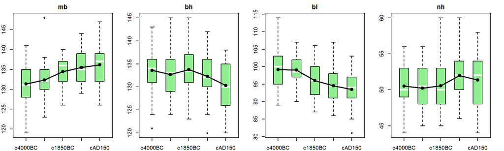

- Os pontos pretos sólidos representam a média da variável correspondente para a época correspondente.
- Em geral, a variável que cria o grupo é chamada de *fator*.
- Os diferentes valores que um fator assume são chamados de *níveis*.
- Nesse caso, há apenas um fator, ‘época’, com cinco níveis (os anos).
- Assim, vamos empregar um modelo de Análise de Variância (ANOVA) de uma via para testar se os vetores médios para grupos diferentes são iguais ou não.

### *Modelo de ANOVA de um fator: Univariado*

Vamos revisar a ANOVA de um fator na situação univariada. Suponha que observamos amostras *independentes* de $g$ grupos

> Amostra 1: $X_{11}, \ldots, X_{1n_1}$ de uma população $N(\mu_1, \sigma^2)$

> Amostra 2: $X_{21}, \ldots, X_{2n_2}$ de uma população $N(\mu_2, \sigma^2)$

> $\vdots$

> Amostras $g$: $X_{g1}, \ldots, X_{gn_g}$ de uma população $N(\mu_g, \sigma^2)$.

Aqui, a notação $X_{ij}$ denota a resposta para o $j$-ésimo indivíduo no $i$-ésimo grupo.

- Suposições:
  - Cada população é normal;
  - grupos/populações tem médias diferentes, mas a mesma variãncia $\sigma^2$;
  - as amostras são mutamente independentes.

Hipótese de interesse: $H_0: \mu_1 = \ldots = \mu_g$ vs. $H_1:$ pelo menos duas médias são diferentes.

Escrevemos o modelo ANOVA como
$$\underbrace{X_{ij}}_{\Big(\substack{\hbox{Resposta
para $j$-ésimo} \\ \hbox{indivíduo no $i$-ésimo grupo}}\Big)} =
\underbrace{\mu_i}_{\Big(\hbox{Média $i$-ésima população}\Big)} +
\underbrace{e_{ij}.}_{\Big(\hbox{erro $N(0, \sigma^2)$}\Big)}$$
Em geral decompomos as médias do grupo como
$$\underbrace{\mu_i}_{\Big(\hbox{média do $i$-ésimo grupo}\Big)} =
\underbrace{\mu}_{\Big(\hbox{média global}\Big)} +
\underbrace{\tau_i.}_{\Big(\hbox{efeito do $i$-ésimo grupo }\Big)}$$
Assim o modelo de ANOVA de um fator é dada por
$$X_{ij}=\mu+\tau_i+e_{ij},\; e_{ij}\stackrel{i.i.d}{\sim}
N(0,\sigma^2).$$

- O efeito de i-ésimo grupo é $\tau_i=$ ( média do i-ésimo grupo - média geral), ou seja
  $$\tau_i=\mu_i-\mu,\;
  i=1,\ldots, g$$
- Muitas vezes colocamos a restrição:
  $$\sum_{i=1}^{g}n_i\tau_i=0.$$
- As estimativas dos parâmetros do modelo de ANOVA
  $$\hat{\mu}=\bar{x},\;\; \hat{\tau}_i=\bar{x}_i-\bar{x}$$
- Motivados pela decomposição acima, também podemos decompor os dados observados da seguinte forma:
  $$\underbrace{x_{ij}}_{\Big(\hbox{observação}\Big)}
  = \underbrace{\bar x}_{\Big(\substack{\hbox{Média amostral} \\
  \hbox{global}}\Big)} + \underbrace{(\bar x_i - \bar
  x)}_{\Big(\substack{\hbox{efeito grupo} \\ \hbox{ estimado}}\Big)} +
  \underbrace{(x_{ij} - \bar x_i)}_{\Big(\hbox{residual}\Big)}.$$
- Note que se $H_0:\tau_1=\tau_2=\ldots=\tau_q=0$ é verdade, isto é, se cada $\tau_i=0$, então cada $\hat{\tau}_i=\bar{x}_i-\bar{x}$ também deve ser próximo de zero.
- Portanto, se observarmos que alguns dos efeitos de grupo, $\bar{x}_i-\bar{x}$, são grandes, devemos rejeitar $H_0.$
- A variabilidade das observações é decomposta em 2 componentes:
  $$\sum_{i=1}^{g}\sum_{j=1}^{n_i}(x_{ij}-\bar{x})^2=\sum_{i=1}^{g}\sum_{j=1}^{n_i}(\bar
  x_i - \bar x)^2+\sum_{i=1}^{g}\sum_{j=1}^{n_i}(x_{ij} - \bar x_i)^2$$
- Para avaliar o efeito do grupo, observamos a soma dos quadrados:
  $$\hbox{Soma de quadrados de tratamento (SQTr)} = \sum_{i=1}^g n_i(\bar
  x_i - \bar x)^2,$$
  $$\hbox{Soma de quadrados do erro (SQE)} =
  \sum_{i=1}^g\sum_{j=1}^{n_i}(x_{ij} - \bar x_i)^2.$$
- O teste $F$ rejeita $H_0$ se
  $$\frac{SQTr/(g - 1)}{SQE / (\sum_i n_i - g)} > F_{g - 1, \sum_i n_i -
  g}(\alpha).$$
- A quantidade do numerador: $SSTr/(g - 1)$ é denominado de quadrado médio do tratamento (QMTr).
- Se a hipótese nula for verdadeira (ou seja, todas as médias do grupo são iguais), então a média da amostra individual $\bar{x}_i$ do $i$-ésimo grupo, deve estar próxima da média geral da amostra combinada $\bar{x}$. Assim, sob $H_0,$ o QMTr teria um valor pequeno.
- Essa quantidade mede o quão semelhantes as amostras são em termos de suas médias. Esta é uma medida de variabilidade entre as amostras.
- A quantidade do denominador: $SQE / (\sum_i n_i - g)$ é denominado de quadrado médio do erro (QME),
- Assim, a estatística de teste acima compara a variabilidade entre amostras e a variabilidade dentro das amostras.

#### *Exemplo-Crânios Egipcios*

Vamos considerar os dados dos crânios Egipcios e considerar apenas uma variável, mb: largura máxima do crânio(mb) e realizar a ANOVA.

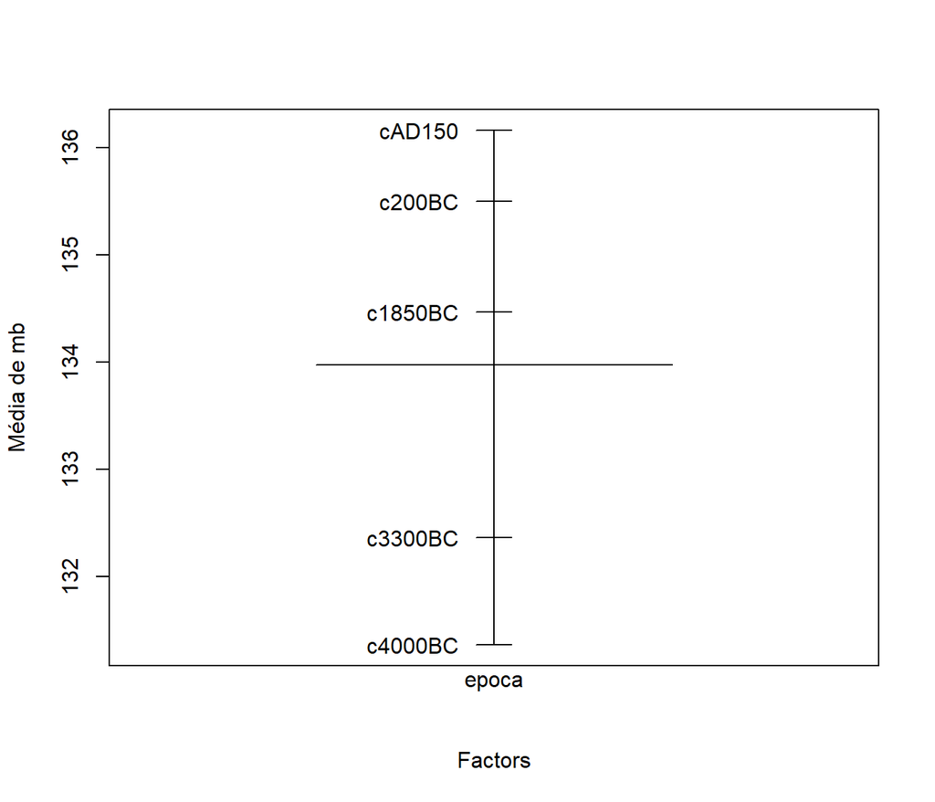

Diferenças nas médias amostrais para diferentes épocas. A longa linha horizontal representa a média geral.

```r
mb <- dat[, 1]
epoca <- skulls$epoch
plot.design(mb ~ epoca,ylab="Média de mb")
```

```r
# one-way anova
fit <- aov(mb ~ epoca)
# ANOVA F-test
summary(fit)
```

```
##              Df Sum Sq Mean Sq F value   Pr(>F)
## epoca         4  502.8  125.71   5.955 0.000183 ***
## Residuals   145 3061.1   21.11
## ---
## Signif. codes:  0 '***' 0.001 '**' 0.01 '*' 0.05 '.' 0.1 ' ' 1
```

- O pequeno p-valor indica que devemos rejeitar $H_0$, ou seja, as médias do grupo não são iguais.
- Note que assumimos que todas as populações tem a mesma variância $\sigma^2$.
- A estimativa de $\sigma^2$ é dado por $QME$. Na tabela ANOVA, tem-se $\hat\sigma^2 = 21,11$.

### Anova Multivariada (MANOVA) com um fator

Suponha que observamos amostras de g grupos independentes:

> Amostra 1: $\boldsymbol{X}_{11}, \ldots, \boldsymbol{X}_{1n_1}$ de uma população $N(\boldsymbol{\mu}_1, \boldsymbol\Sigma)$

> Amostra 2: $\boldsymbol{X}_{21}, \ldots, \boldsymbol{X}_{2n_2}$ de uma população $N(\boldsymbol{\mu}_2, \boldsymbol\Sigma)$

> $\vdots$

> Amostra $g$: $\boldsymbol{X}_{g1}, \ldots, \boldsymbol{X}_{gn_g}$ de uma população $N(\boldsymbol{\mu}_g, \boldsymbol\Sigma)$
- Suposições:
  - cada população é normal multivariada;
  - cada grupo/população tem vetor de médias diferentes mas a mesma covariância;
  - as amostras são independentes.
- Deseja-se avaliar as hipóteses
  $$\begin{array}{l}H_0:\boldsymbol{\mu}_1=\boldsymbol{\mu}_2=\ldots
  \boldsymbol{\mu}_g=\mu\mbox{ contra }\\H_1: {\mbox{ pelo menos um
  $\boldsymbol{\mu}_i$ diferente}}\end{array}$$
- Para isso, vamos considerar a reparametrização
  $$\boldsymbol{\mu}_{k} = \boldsymbol{\mu} +
  \boldsymbol\tau_k, \ k=1,\ldots,g,$$
  e então avaliar se
  $$\begin{array}{l}H_0:\boldsymbol{\tau}_1=\boldsymbol{\tau}_2=\ldots
  \boldsymbol{\tau}_g=\boldsymbol{0}\mbox{ contra }\\H_1: {\mbox{ pelo
  menos um $\boldsymbol{\tau}$ diferente de
  $\boldsymbol{0}$}}\end{array}$$
- O modelo de MANOVA de um fator pode-se escrever:
  $$\boldsymbol{X}_{kj} = \boldsymbol\mu +
  \boldsymbol\tau_{k} + \boldsymbol\epsilon_{kj},\;j=1,\ldots,n_k,
  k=1,\ldots,g$$
- Suposições:
  - $\boldsymbol\epsilon_{kj}\stackrel{ind}{\sim} N_p(\boldsymbol{0},\Sigma)$,
  - $\boldsymbol\mu$ é o vetor de média geral,
  - $\boldsymbol\tau_{k}$ é o vetor de efeito do $k-$ ésimo tratamento,
  - $\sum_{k=1}^{g} n_k\boldsymbol\tau_{k}=\boldsymbol{0}$.
- Como ao caso univariado, escrevemos a resposta multivariada como
  $$\underbrace{\boldsymbol{x}_{ij}}_{\Big(\hbox{Observação}\Big)} =
  \underbrace{\bar{ \boldsymbol{x}}}_{\Big(\substack{\hbox{Média} \\
  \hbox{amostral geral}}\Big)} + \underbrace{(\bar{\boldsymbol{x}}_i -
  \bar {\boldsymbol{x}})}_{\Big(\substack{\hbox{estimativa do} \\ \hbox{
  efeito de grupo }}\Big)} + \underbrace{(\boldsymbol{x}_{ij} - \bar{
  \boldsymbol{x}}_i)}_{\Big(\hbox{Residual}\Big)}.$$
- Aqui, cada termo é um vetor, portanto, precisamos de um análogo mutivariado da soma univariada dos quadrados, a matriz da soma dos quadrados e produtos cruzados:
- Da decomposição da variabilidade dos dados em torno da média em variabilidade intra e entre tratamentos. Temos que
  $$\begin{array}{l}
  (\boldsymbol{x}_{kj}-\overline{\boldsymbol{x}})(\boldsymbol{x}_{kj}-\overline{\boldsymbol{x}})^\top
  =
  \left[(\boldsymbol{x}_{kj} {-\overline{\boldsymbol{x}}_k}) +
  ({\overline{\boldsymbol{x}}_k}- \overline{\boldsymbol{x}})\right]
  \left[(\boldsymbol{x}_{kj}{-\overline{\boldsymbol{x}}_k} )+
  (\overline{\boldsymbol{x}}_k-\overline{\boldsymbol{x}})\right]^\top
  =\\
  = (\boldsymbol{x}_{kj}-
  \overline{\boldsymbol{x}}_k)(\boldsymbol{x}_{kj}-
  \overline{\boldsymbol{x}}_k )^\top+
  (\boldsymbol{x}_{kj}- \overline{\boldsymbol{x}}_k)
  (\overline{\boldsymbol{x}}_k-\overline{\boldsymbol{x}})^\top+(\overline{\boldsymbol{x}}_k-
  \overline{\boldsymbol{x}})(\boldsymbol{x}_{kj}-
  \overline{\boldsymbol{x}}_k )^\top \\ + (\overline{\boldsymbol{x}}_k-
  \overline{\boldsymbol{x}})(\overline{\boldsymbol{x}}_k-\overline{\boldsymbol{x}})^\top
  \end{array}$$
- Somando em j, nas componentes
  $$\begin{array}{l}
  \displaystyle{\sum_{j=1}^{n_k}} \left[(\boldsymbol{X}_{kj}-
  \overline{\boldsymbol{X}}_k)
  (\overline{\boldsymbol{X}}_k-\overline{\boldsymbol{X}})^\top\right]=\\
  \displaystyle{\sum_{j=1}^{n_k}} \left[(\boldsymbol{X}_{kj}-
  \overline{\boldsymbol{X}}_k)\right]
  (\overline{\boldsymbol{X}}_k-\overline{\boldsymbol{X}})^\top=\\
  (\displaystyle{\sum_{j=1}^{n_k}}
  \boldsymbol{X}_{kj}- n_k\overline{\boldsymbol{X}}_k)
  (\overline{\boldsymbol{X}}_k-\overline{\boldsymbol{X}})^\top=\\
  (\displaystyle{\sum_{j=1}^{n_k}} \boldsymbol{X}_{kj}
  - \displaystyle{\sum_{j=1}^{n_k}} \boldsymbol{X}_{kj})
  (\overline{\boldsymbol{X}}_k-\overline{\boldsymbol{X}})^\top= 0 \\
  \end{array}$$
- Idem para
  $$\begin{array}{l}
  \displaystyle\sum_{j=1}^{n_k} (\overline{\boldsymbol{X}}_k-
  \overline{\boldsymbol{X}})(\boldsymbol{X}_{kj}-
  \overline{\boldsymbol{X}}_k )^\top= 0 \\
  \end{array}$$
- Daí a soma em $j$ e em $k$, resulta
  $$\begin{array}{l} \displaystyle
  \underbrace{\sum_{k=1}^{g}\sum_{j=1}^{n_k}(\boldsymbol{X}_{kj}-\overline{\boldsymbol{X}})(\boldsymbol{X}_{kj}-\overline{\boldsymbol{X}})^\top}_{T}
  =\\ \ \
  =\underbrace{\displaystyle\sum_{k=1}^{g}n_k(\overline{\boldsymbol{X}}_k-\overline{\boldsymbol{X}})(\overline{\boldsymbol{X}}_k-\overline{\boldsymbol{X}})^\top}_{B} +
  \underbrace{\sum_{k=1}^{g}\sum_{j=1}^{n_k}(\boldsymbol{X}_{kj}-\overline{\boldsymbol{X}}_k)(\boldsymbol{X}_{kj}-\overline{\boldsymbol{X}}_k)^\top}_{W}
  \end{array}$$
- Assim, $T = B+ W$, com
  - $T$: soma de quadrados e produtos cruzados *total*
  - $B$: soma de quadrados e produtos cruzados *entre tratamentos*
  - $W$: soma de quadrados e produtos cruzados *intra tratamento* (dentro de tratamentos)
- Consideramos as somas de quadrados e produtos cruzados
  $$T = \sum_{k=1} ^{g} \sum_ {j=1}^{n_k}
  (\boldsymbol{X}_{kj}-\overline{\boldsymbol{X}})(\boldsymbol{X}_{kj}-\overline{\boldsymbol{X}})^\top
  \mbox{(total)}$$
  $$B = \sum_{k=1}
  ^{g}n_k (\overline{\boldsymbol{X}}_k -
  \overline{\boldsymbol{X}})(\overline{\boldsymbol{X}}_k -
  \overline{\boldsymbol{X}})^\top \mbox{(entre)}$$
  $$W = \sum_{k=1} ^{g} \sum_ {j=1}^{n_k}
  (\boldsymbol{X}_{kj}-\overline{\boldsymbol{X}}_k)(\boldsymbol{X}_{kj}-\overline{\boldsymbol{X}}_k)^\top
  \mbox{(dentro)}$$
- Temos
  $$T = B + W$$
  $$SQT = SQTrat + SQRes$$
- Como supomos que todos os grupos têm a mesma variância, podemos considerar como estimativa de $\Sigma$:
  $$S_{pooled} = W = \sum_{k=1} ^{g} \sum_
  {j=1}^{n_k}
  (\boldsymbol{X}_{kj}-\overline{\boldsymbol{X}}_k)(\boldsymbol{X}_{kj}-\overline{\boldsymbol{X}}_k)^\top$$

  $$W = (n_1-1) \boldsymbol{S}_1 + (n_2-1)
  \boldsymbol{S}_2 + \ldots + (n_g-1) \boldsymbol{S}_g.$$
- A hipótese é rejeitada se a razão,
  $$\Lambda^\star =
  \frac{|W|}{|W+B|}=\frac{\Bigg|\sum_{k=1} ^{g} \sum_
  {j=1}^{n_k}(\boldsymbol{X}_{kj}-\overline{\boldsymbol{X}}_k)(\boldsymbol{X}_{kj}-\overline{\boldsymbol{X}}_k)^\top\Bigg|}{\Bigg|\sum_{k=1}
  ^{g} \sum_ {j=1}^{n_k}
  (\boldsymbol{X}_{kj}-\overline{\boldsymbol{X}})(\boldsymbol{X}_{kj}-\overline{\boldsymbol{X}})^\top\Bigg|
  }$$

for muito pequeno.

- O determinante de uma matriz de covariância é chamado de variância generalizada (Johnson & Wichern, 2007).
- $\Lambda^\star$ é conhecido com lambda de Wilk.
- É equivalente à estatística da razão de verossimilhança.
- A distribuição de $\Lambda^\star$ foi estudada em diferentes casos e existem tabelas com os resultados (ver Tabela 6.3 de Johnson & Wichern,2007).
- $\Lambda^\star$ é uma razão de variâncias amostrais generalizadas
  $$\Lambda^\star=
  \frac{|W|}{|T|}=\frac{\prod_{i=1}^{p}\lambda_i}{\prod_{i=1}^{p}\lambda_i^*}$$
  onde $\lambda_i$s são autovalores de $W$ e $\lambda_i^*$s são autov/alores de $T$
- Se $H_0:\boldsymbol\tau_1=\ldots=\boldsymbol\tau_g=\boldsymbol{0}$ é verdadeiro, então B está próximo de $\boldsymbol{0}$
  - $\Longrightarrow$ $T\approx W$
  - $\Longrightarrow$ $\lambda_i\approx \lambda_i^*$
  - $\Longrightarrow$ $\Lambda^\star$ é próximo de 1.
- Se $H_0:\boldsymbol\tau_1=\ldots=\boldsymbol\tau_g=\boldsymbol{0}$ é falso, então B não está próximo de $\boldsymbol{0}$
  - $\Longrightarrow$ os valores nas diagonais de $T,$ que serão positivos grandes.
  - $\Longrightarrow$ $\lambda_i< \lambda_i^*$
  - $\Longrightarrow$ $\Lambda^\star$ é pequena .
- A distribuição exata de $\Lambda^*$ pode ser derivada para casos especiais de $p$ e $g.$

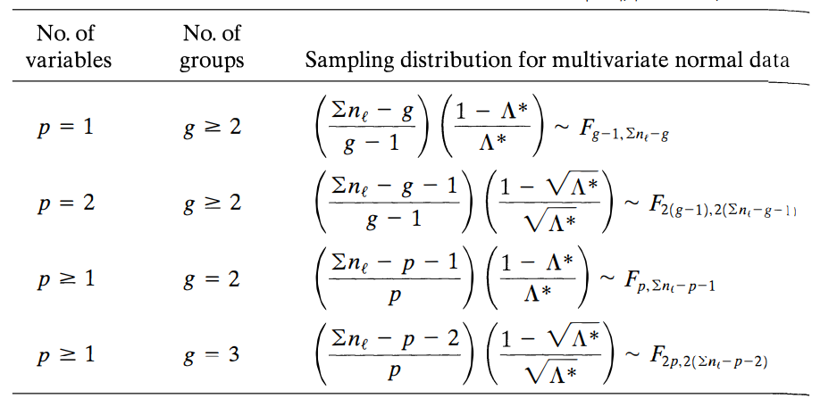

- Bartlett[^1] mostrou que se $H_0$ é verdadeira e $\sum_{k=1}^{g}n_k = n$ é grande, então
  $$\displaystyle-\left(n-1-\frac{p+g}{2}\right)\log(\Lambda^{\star})\sim
  \chi^2_{p(g-1)}.$$
- É possível obter distribuições exatas para $\Lambda^*$ de Wilks
- Além disso, existem outras estatísticas disponíveis para testar $H_0.$
  - Traço de Pillai
  - Traço de Hotelling
  - Maior autovalor de Roy
- Todas as quatro estatísticas são equivalentes (mesmo poder) para amostras grandes.
- Para amostras (relativamente) pequenas, as estatísticas Wilks, Pillar e Hotelling são equivalentes.
- Traço de Pillai tem se mostrado mais robusto com relação à não normalidade.
- Para detalhes, ver Johnson & Wichern (2007) cap 6.

#### Exemplo

Considere os dados de Crânios Egípicios, mas com todas as quatro variáveis. Lembre-se de que existem cinco grupos (cinco épocas) e queremos comparar a média de (mb, bh, bl, nh) entre os cinco grupos.

```r
epoca <- skulls$epoch

n=nrow(dat)
g=5
p=4
A1=dat[epoca=="c4000BC",]
A2=dat[epoca=="c3300BC",]
A3=dat[epoca=="c1850BC",]
A4=dat[epoca=="c200BC",]
A5=dat[epoca=="cAD150",]
################################################################
# Média de grupos
################################################################
gmeans <- aggregate(dat, by = list(epoca=epoca), FUN = mean)
gmeans
```

```
##     epoca       mb       bh       bl       nh
## 1 c4000BC 131.3667 133.6000 99.16667 50.53333
## 2 c3300BC 132.3667 132.7000 99.06667 50.23333
## 3 c1850BC 134.4667 133.8000 96.03333 50.56667
## 4  c200BC 135.5000 132.3000 94.53333 51.96667
## 5  cAD150 136.1667 130.3333 93.50000 51.36667
```

```r
###############################################################
# As matrizes de covariâncias dos grupos
###############################################################
S1=cov(A1)
S1
```

```
##           mb         bh         bl         nh
## mb 26.309195  4.1517241  0.4540230  7.2459770
## bh  4.151724 19.9724138 -0.7931034  0.3931034
## bl  0.454023 -0.7931034 34.6264368 -1.9195402
## nh  7.245977  0.3931034 -1.9195402  7.6367816
```

```r
S2=cov(A2)
S2
```

```
##           mb        bh         bl        nh
## mb 23.136782  1.010345  4.7678161 1.8425287
## bh  1.010345 21.596552  3.3655172 5.6241379
## bl  4.767816  3.365517 18.8919540 0.1908046
## nh  1.842529  5.624138  0.1908046 8.7367816
```

```r
S3=cov(A3)
S3
```

```
##            mb          bh         bl          nh
## mb 12.1195402  0.78620690 -0.7747126  0.89885057
## bh  0.7862069 24.78620690  3.5931034 -0.08965517
## bl -0.7747126  3.59310345 20.7229885  1.67011494
## nh  0.8988506 -0.08965517  1.6701149 12.59885057
```

```r
S4=cov(A4)
S4
```

```
##           mb        bh        bl       nh
## mb 15.362069 -5.534483 -2.172414 2.051724
## bh -5.534483 26.355172  8.110345 6.148276
## bl -2.172414  8.110345 21.085057 5.328736
## nh  2.051724  6.148276  5.328736 7.964368
```

```r
S5=cov(A5)
S5
```

```
##            mb         bh         bl         nh
## mb 28.6264368 -0.2298851 -1.8793103 -1.9942529
## bh -0.2298851 24.7126437 11.7241379  2.1494253
## bl -1.8793103 11.7241379 25.5689655  0.3965517
## nh -1.9942529  2.1494253  0.3965517 13.8264368
```

```r
##################################################################
#  Estatisitca de Wilks
###################################################################
W=(nrow(A1)-1)*S1+ (nrow(A2)-1)*S2+(nrow(A3)-1)*S3+ (nrow(A4)-1)*S4+(nrow(A5)-1)*S5

T=(n-1)*cov(dat)

B=T-W

Lam=det(W)/det(T)
cat("Estatística de Wilks \n", Lam)
```

```
## Estatística de Wilks
##  0.6635858
```

```r
Eb=-(n-1+(p+g)/2)*log(Lam)
cat("Estatística de Bartlet \n", Eb)
```

```
## Estatística de Bartlet
##  62.94991
```

```r
qchisq(0.95,4*4)
```

```
## [1] 26.29623
```

```r
cat("Valor crítico: \n", qchisq(0.95,df=p*(g-1)))
```

```
## Valor crítico:
##  26.29623
```

```r
pvalor=1-pchisq(Eb,df=p*(g-1))

cat("valor p:\n", pvalor)
```

```
## valor p:
##  1.654149e-07
```

```r
#########################################################
# manova
# summary(object,
# test = c("Pillai", "Wilks", "Hotelling-Lawley", "Roy"),
# intercept = FALSE, tol = 1e-7, ...)
########################################################

fit_1 <- manova(dat ~ epoca)

summary( fit_1, test = "Wilks")
```

```
##            Df   Wilks approx F num Df den Df   Pr(>F)
## epoca       4 0.66359   3.9009     16 434.45 7.01e-07 ***
## Residuals 145
## ---
## Signif. codes:  0 '***' 0.001 '**' 0.01 '*' 0.05 '.' 0.1 ' ' 1
```

```r
summary( fit_1, test = "Pillai")
```

```
##            Df  Pillai approx F num Df den Df    Pr(>F)
## epoca       4 0.35331    3.512     16    580 4.675e-06 ***
## Residuals 145
## ---
## Signif. codes:  0 '***' 0.001 '**' 0.01 '*' 0.05 '.' 0.1 ' ' 1
```

```r
summary( fit_1, test = "Hotelling-Lawley")
```

```
##            Df Hotelling-Lawley approx F num Df den Df    Pr(>F)
## epoca       4          0.48182    4.231     16    562 8.278e-08 ***
## Residuals 145
## ---
## Signif. codes:  0 '***' 0.001 '**' 0.01 '*' 0.05 '.' 0.1 ' ' 1
```

```r
summary( fit_1, test = "Roy")
```

```
##            Df    Roy approx F num Df den Df    Pr(>F)
## epoca       4 0.4251    15.41      4    145 1.588e-10 ***
## Residuals 145
## ---
## Signif. codes:  0 '***' 0.001 '**' 0.01 '*' 0.05 '.' 0.1 ' ' 1
```

#### Comparação Multiplas

- Quando a hipótese de efeitos de igualdade de tratamento é rejeitada, aqueles efeitos que levaram à rejeição da hipótese são de interesse.
- Para comparações de pares, a abordagem de Bonferroni pode ser usada para construir intervalos de confiança simultâneos para os componentes das diferenças $\boldsymbol{\tau}_k-\boldsymbol{\tau}_{\ell}$ (ou $\boldsymbol{\mu}_k-\boldsymbol{\mu}_{\ell}$).
- Pois, $\boldsymbol{\tau}_k-\boldsymbol{\tau}_{\ell}=\boldsymbol{\mu}_k-\boldsymbol{\mu}_{\ell}$
- Esses intervalos são mais curtos do que aqueles obtidos para todos os contrastes e exigem valores críticos a estatística $t$ univariada.
- Seja $\tau_{ki}$ o i-ésimo componente de $\boldsymbol{\tau}_k$. Uma vez que $\boldsymbol{\tau}_k$ é estimado por $\hat{\boldsymbol{\tau}}_k=\bar{\boldsymbol{x}}_k-\bar{\boldsymbol{x}}.$
  $$\hat{\tau}_{ki}=\bar{x}_{ki}-\bar{x}_i$$
  e
  $$\hat\tau_{ki}- \hat\tau_{\ell i}=\bar{x}_{ki}-\bar{x}_{\ell i}$$
  é a diferença de duas médias amostrais independentes.
- Note que
  $$Var(\bar{X}_{ki}-\bar{X}_{\ell
  i})=\left(\frac{1}{n_k}+\frac{1}{n_{\ell}}\right)\sigma_{ii}$$
  onde $\sigma_{ii}$ é o $i$-ésimo elemento diagonal de $\Sigma$.
- Sob as suposições do modelo de MANOVA $\bar{X}_{ki}-\bar{X}_{\ell i}$ tem distribuição normal com média $\mu_{ki}-\mu_{\ell i}$ e variância $Var(\bar{X}_{ki}-\bar{X}_{\ell i}).$
- A estimativa de $ Var({X}*{ki}-{X}*{i})$ é
  $$\widehat{Var(\bar{X}_{ki}-\bar{X}_{\ell
  i})}=\left(\frac{1}{n_k}+\frac{1}{n_{\ell}}\right)\frac{w_{ii}}{n-g}$$
  onde $w_{ii}$ é o $i$-ésimo elemento diagonal de $W$ e $n=n_1+\ldots+n_g.$
- Existem $p$ variáveis e $g(g-1)/2$ pares diferenças de pares, então cada intervalo baseado na distribuição $t$ de duas amostras, consideraremos o valor crítico $t_{n-g}(\alpha/2m)$, onde
  $$m=pg(g-1)/2.$$
  é o número de comparações de confiança simultâneas.
- No modelo de MANOVA, um intervalo de pelo menos $100(1-\alpha)\%$ de confiança para $\mu_{ki}-\mu_{\ell i}$ é dada por
  $$\bar{x}_{ki}-\bar{x}_{\ell i}\mp
  t_{n-g}\left(\frac{\alpha}{pg(g-1)}\right)\sqrt{\left(\frac{1}{n_k}+\frac{1}{n_{\ell}}\right)\frac{w_{ii}}{n-g}},$$
  para $i=1,\ldots,p,$ ; $\ell < k=1,\ldots, g.$

```r
library(emmeans)
# Manova
fit_1 <- manova(dat ~ epoca)
#####################################################
# médias da variável resposta mb
mbmedia <- emmeans(fit_1, "epoca", weights=c(1,0,0,0))
mbmedia
```

```
##  epoca   emmean    SE  df lower.CL upper.CL
##  c4000BC    131 0.839 145      130      133
##  c3300BC    132 0.839 145      131      134
##  c1850BC    134 0.839 145      133      136
##  c200BC     136 0.839 145      134      137
##  cAD150     136 0.839 145      135      138
##
## Results are averaged over the levels of: rep.meas
## Confidence level used: 0.95
```

```r
###
# numero de variavveis
p <- 4
# numero de gropos
g <- 5
# nivel de significance
alpha <- 0.05
# number of comparison
m <- p*g*(g-1)/2
alpha.n <- alpha/m
#Definido os contraste
cont <- contrast(mbmedia, "pairwise")
# differença 2 a 2 de `mb`
bb <- confint(cont, level = 1-alpha.n, adj="none")
bb
```

```
##  contrast          estimate   SE  df lower.CL upper.CL
##  c4000BC - c3300BC   -1.000 1.19 145    -4.91    2.905
##  c4000BC - c1850BC   -3.100 1.19 145    -7.01    0.805
##  c4000BC - c200BC    -4.133 1.19 145    -8.04   -0.228
##  c4000BC - cAD150    -4.800 1.19 145    -8.71   -0.895
##  c3300BC - c1850BC   -2.100 1.19 145    -6.01    1.805
##  c3300BC - c200BC    -3.133 1.19 145    -7.04    0.772
##  c3300BC - cAD150    -3.800 1.19 145    -7.71    0.105
##  c1850BC - c200BC    -1.033 1.19 145    -4.94    2.872
##  c1850BC - cAD150    -1.700 1.19 145    -5.61    2.205
##  c200BC - cAD150     -0.667 1.19 145    -4.57    3.239
##
## Results are averaged over the levels of: rep.meas
## Confidence level used: 0.99875
```

### Exemplo

Um experimento com 20 replicas foi realizado para avaliar o efeito 3 tratamentos (I, II e III) na altura ($x_1$) e no diâmetro ($x_2$) de plantas. Note que $n_i=20$ (i=1,2,3) O vetor médio geral e os vetores médios para cada condição:
$$\bar{\boldsymbol{x}}=\begin{pmatrix}
33,62\\
18,25
\end{pmatrix},\;\bar{\boldsymbol{x}}_1=\begin{pmatrix}
38,55\\
23,70
\end{pmatrix},\; \bar{\boldsymbol{x}}_2=\begin{pmatrix}
34,00\\
18,20
\end{pmatrix},\; \bar{\boldsymbol{x}}_3=\begin{pmatrix}
28,30\\
12,85
\end{pmatrix}$$
A matrizes de covariâncias amostrais:
$$S_1=\begin{pmatrix}
49,52 &13,17\\
13,17& 7,59
\end{pmatrix},\; S_2=\begin{pmatrix}
27,47 &4,21\\
4,21& 4,48
\end{pmatrix},\; S_3=\begin{pmatrix}
16,33 &4,42\\
4,42 &3,19
\end{pmatrix}$$
- (a) Escreva o modelo para esse problema, identificando cada componente e a respecitiva suposições. O modelo
$$\boldsymbol{X}_{kj} = \boldsymbol\mu +
\boldsymbol\tau_{k} + \boldsymbol\epsilon_{kj},\; j=1,\ldots,20,
k=1,2,3$$

- Suposições:
  - $\boldsymbol{X}_{kj}=(X_{1kj},X_{2kh})$: vetor da variável resposta, para $j$-esima u.e e $k$-ésimo tratamento.
  - $\boldsymbol\epsilon_{kj}\stackrel{ind}{\sim} N_p(\boldsymbol{0},\Sigma)$,
  - $\boldsymbol\mu$ é o vetor de média geral,
  - $\boldsymbol\tau_k$ é o vetor de efeito do $k-$ ésimo tratamento,
  - $\sum_{k=1}^{g} n_k\boldsymbol\tau_k=\boldsymbol{0}$.

-(b) Avalie o efeito dos tratamentos. Use $\alpha=0,1$

-(c) Avalie entre que tratamentos há diferenças significativas utilizado a aproximação de Bonferroni. Use $\alpha=0,1$

### MANOVA com 2 fatores

Considere a extrusão de dados de filme plástico[^2]. A descrição dos dados (conforme fornecida em Johnson e Wichern) é fornecida abaixo:

“As condições ideais para extrusão de filme plástico foram examinadas usando uma técnica chamada Operações Evolucionárias. dois níveis dos fatores *taxa de extrusão* e *quantidade de um aditivo*. As medições foram repetidas cinco vezes em cada combinação dos níveis dos fatores.”

```r
data <- read.table("T6-4.txt", header = F)
colnames(data) <- c("rate", "additive" ,"Tear", "Gloss", "Opacity")
x = data.frame(data[,3:5])
rate = as.factor(data[,1])
additive = as.factor(data[,2])
head(data)
```

```
##   rate additive Tear Gloss Opacity
## 1    0        0  6.5   9.5     4.4
## 2    0        0  6.2   9.9     6.4
## 3    0        0  5.8   9.6     3.0
## 4    0        0  6.5   9.6     4.1
## 5    0        0  6.5   9.2     0.8
## 6    0        1  6.9   9.1     5.7
```

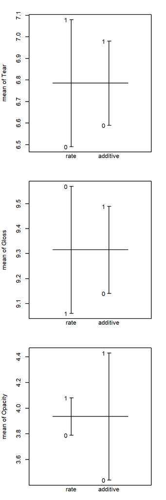

Média amostrais do Tear (acima), Gloss (centro), e Opacity (embaixo) para diferentes dos fatores.

```r
# design plo
par(mfrow = c(3,1), mar = c(2,4,2,2))
with(x, {plot.design(Tear ~ rate * additive)})
with(x, {plot.design(Gloss  ~ rate * additive)})
with(x, {plot.design(Opacity ~ rate * additive)})
```

- 0 objetivo é avaliar os principais efeitos dos dois fatores e sua interação nas três variáveis de resposta.

## ANOVA de 2 fatores: univariada

Em geral, suponha que existam níveis **$g$ do fator 1** e níveis **$b$ do fator 2**. Observamos $n$ observações independentes para cada uma das combinações $gb$ de níveis de fatores. Assumimos um tamanho de amostra igual $n$ apenas para simplificar. Em geral, tamanhos de amostra desiguais também são permitidos.

Denote a $r$th observação no nível $\ell$ do fator 1 e nível $k$ do fator 2 por $X_{\ell k r}$. A média populacional no nível $\ell$ do fator 1 e no nível $k$ do fator 2 é denotada por $\mu_{\ell k}$

Considere a seguinte decomposição:
$$\underbrace{\mu_{\ell k}}_{\hbox{Média do grupo $(\ell,k)$} } =
\underbrace{\mu}_{\hbox{Média geral}} +
\underbrace{\tau_\ell}_{\hbox{Efieto do fator 1}} +
\underbrace{\beta_k}_{\hbox{Efeito do fator 2}} +
\underbrace{\gamma_{\ell k}}_{\hbox{Efeito da iteração}},$$
onde $\mu$ é a média geral, $\tau_\ell$ é o efeito fixo do fator 1, $\beta_k$ é o efeito fixo do fator 2 e $\gamma_{\ell k}$ é a interação entre os dois fatores. Normalmente colocamos restrições $\sum_{\ell=1}^g \tau_\ell = \sum_{k=1}^b \beta_k = \sum_{\ell=1}^g \gamma_{\ell k} = \sum_{k =1}^b \gamma_{\ell k} = 0.$ A soma dos quadrados para os efeitos dos fatores e sua interação são mostrados abaixo.

$$\begin{matrix}
\text{Fonde de variação} & \text{Suma de quadrados (SQ) }&
\text{Graus de liberdade}& \text{Quadrado médio}\\
Fator 1 & SQA = \displaystyle\sum_{\ell=1}^{g} bn (\bar{x}_{\ell
\cdot} - \bar{x})^2 & g - 1 & QMA = \frac{SQA}{g-1}\\
Fator 2 & SQB = \displaystyle\sum_{k=1}^{b} gn (\bar{x}_{\cdot k} -
\bar{x})^2 & b - 1 & QMB = \frac{SQB}{b-1}\\
Interação & SQAB = \displaystyle\sum_{\ell=1}^{g} \sum_{k=1}^{b} n
(\bar x_{\ell k} - \bar{x}_{\ell \cdot} - \bar{x}_{\cdot k} + \bar{x})^2
& (g - 1)(b-1) & QMAB = \frac{SQAB}{(g - 1)(b-1)} \\
Residual & SQE = \displaystyle\sum_{\ell=1}^{g} \sum_{k=1}^{b}
\sum_{r=1}^{n} (x_{\ell k r} - \bar{x}_{\ell k})^2 & gb(n-1) &
QME = \frac{SQE}{gb(n-1)}\\
\end{matrix}$$

- As estatísticas de teste para testar o efeito principal do fator 1; do fator 2; interação entre os dois fatores são mostrados abaixo:
  $$F_A=\frac{\textrm{QMA}}{\textrm{QME}},
  \quad
  F_B= \frac{\textrm{QMB}}{\textrm{QME}}, \quad
  F_{AB}= \frac{\textrm{QMAB}}{\textrm{QME}}$$
- Rejeitamos $H_0$ (sem efeito) se a estatística de teste correspondente for maior que um valor crítico de $F$ apropriado. Normalmente, **testamos a interação primeiro**; se concluirmos que não há efeito de interação, só então testamos os efeitos principais de cada fator.
- Vamos considerar apenas a variável `resistência ao rasgo`, “Tear”, e realizar anova de 2 fatores. Um gráfico de interação é mostrado na Figura .

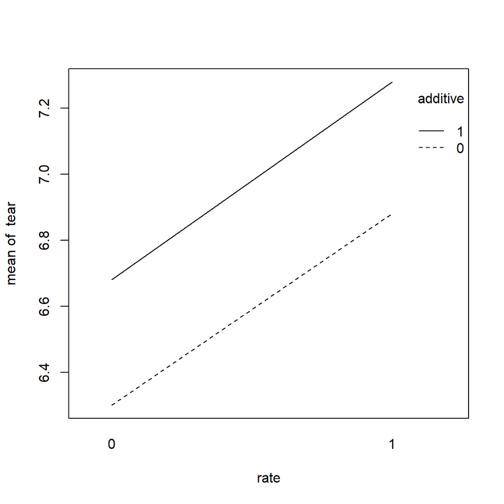

Gráfico da Interação

```r
tear <- x[, 1]
res <- lm(tear ~ rate*additive)
out <- anova( res )
out
```

```
## Analysis of Variance Table
##
## Response: tear
##               Df Sum Sq Mean Sq F value   Pr(>F)
## rate           1 1.7405 1.74050 15.7868 0.001092 **
## additive       1 0.7605 0.76050  6.8980 0.018330 *
## rate:additive  1 0.0005 0.00050  0.0045 0.947143
## Residuals     16 1.7640 0.11025
## ---
## Signif. codes:  0 '***' 0.001 '**' 0.01 '*' 0.05 '.' 0.1 ' ' 1
```

- Começamos olhando para o termo de interação: o valor p indica que não há efeito de interação. Assim, somos livres para examinar os principais efeitos dos fatores. Ambos os fatores têm valores de p significativos ($<0,05$), indicando que a média das respostas difere entre os vários grupos.
- Como não há efeito de interação significativo, podemos querer reajustar o modelo apenas com os efeitos principais:

```r
res.add <-lm(tear ~rate+additive)
out.add <-anova( res.add )
out.add
```

```
## Analysis of Variance Table
##
## Response: tear
##           Df Sum Sq Mean Sq F value    Pr(>F)
## rate       1 1.7405 1.74050  16.769 0.0007549 ***
## additive   1 0.7605 0.76050   7.327 0.0149597 *
## Residuals 17 1.7645 0.10379
## ---
## Signif. codes:  0 '***' 0.001 '**' 0.01 '*' 0.05 '.' 0.1 ' ' 1
```

- Os efeitos dos fatores têm valores de p significativos ($<0,05$), indicando que a média das respostas difere entre os vários grupos.

### MANOVA com 2 fatores

- Para a MANOVA de 2 fatores procede-se de maneira semelhante ao caso univariado; simplesmente substituímos a soma dos quadrados pelas matrizes de produtos cruzados correspondentes.
- Por exemplo, a soma dos quadrados para o fator A pode ser calculada como $SQA = \displaystyle\sum_{\ell=1}^{g} bn (\bar{\boldsymbol{x}}_{\ell \cdot} - \bar{\ x})(\bar{\boldsymbol{x}}_{\ell \cdot} - \bar{\boldsymbol{x}})^T$. Cada efeito de fator e sua interação podem ser testados usando a estatística lambda de Wilks.

```r
x = as.matrix(data[,3:5])
rate = as.factor(data[,1])
additive = as.factor(data[,2])
res=lm(x~rate*additive)
fit=manova(res)
summary(fit, test="Wilks")
```

```
##               Df   Wilks approx F num Df den Df   Pr(>F)
## rate           1 0.38186   7.5543      3     14 0.003034 **
## additive       1 0.52303   4.2556      3     14 0.024745 *
## rate:additive  1 0.77711   1.3385      3     14 0.301782
## Residuals     16
## ---
## Signif. codes:  0 '***' 0.001 '**' 0.01 '*' 0.05 '.' 0.1 ' ' 1
```

- Chegamos a conclusões muito semelhantes às anteriores: não há evidência de um efeito de interação, mas os efeitos principais de ambos os fatores são significativos
- Também podemos extrair resultados ANOVA univariados para variáveis individuais.

```r
summary.aov(res)
```

```
##  Response Tear :
##               Df Sum Sq Mean Sq F value   Pr(>F)
## rate           1 1.7405 1.74050 15.7868 0.001092 **
## additive       1 0.7605 0.76050  6.8980 0.018330 *
## rate:additive  1 0.0005 0.00050  0.0045 0.947143
## Residuals     16 1.7640 0.11025
## ---
## Signif. codes:  0 '***' 0.001 '**' 0.01 '*' 0.05 '.' 0.1 ' ' 1
##
##  Response Gloss :
##               Df Sum Sq Mean Sq F value  Pr(>F)
## rate           1 1.3005 1.30050  7.9178 0.01248 *
## additive       1 0.6125 0.61250  3.7291 0.07139 .
## rate:additive  1 0.5445 0.54450  3.3151 0.08740 .
## Residuals     16 2.6280 0.16425
## ---
## Signif. codes:  0 '***' 0.001 '**' 0.01 '*' 0.05 '.' 0.1 ' ' 1
##
##  Response Opacity :
##               Df Sum Sq Mean Sq F value Pr(>F)
## rate           1  0.421  0.4205  0.1036 0.7517
## additive       1  4.901  4.9005  1.2077 0.2881
## rate:additive  1  3.960  3.9605  0.9760 0.3379
## Residuals     16 64.924  4.0578
```

- Também podemos examinar os contrastes envolvendo os dois fatores *desde que os efeitos da interação sejam desprezíveis*. Podemos usar a biblioteca `emmeans`.
- Em nosso exemplo, suponha que estamos interessados no fator ‘rate’ (contraste 0 vs 1).
- Precisamos começar com a saída ANOVA univariada *para cada variável* e chamar a função `emmeans()` para estimar as médias amostrais para cada nível do fator de interesse.
- Demonstramos essa abordagem para a variável `Tear`.Já sabemos que o efeito da interação não é significativo e, portanto, podemos ajustar um modelo aditivo.

```r
library(emmeans)
# Extract tear and run ANOVA
tear <- x[, 1]
res.tear <- lm(tear ~ rate * additive)
# sample means
mean.rate <- emmeans(res.tear, "rate")
mean.rate
```

```
##  rate emmean    SE df lower.CL upper.CL
##  0      6.49 0.105 16     6.27     6.71
##  1      7.08 0.105 16     6.86     7.30
##
## Results are averaged over the levels of: additive
## Confidence level used: 0.95
```

- Em seguida, chamamos a função `pairs()` para calcular todos os contrastes de pares; aqui como a taxa tem apenas dois níveis, teremos apenas um contraste.

```r
pairs(mean.rate)
```

```
##  contrast      estimate    SE df t.ratio p.value
##  rate0 - rate1    -0.59 0.148 16  -3.973  0.0011
##
## Results are averaged over the levels of: additive
```

- Finalmente, vamos construir intervalos de Bonferroni ajustando para todos os contrastes de pares possíveis dentro do fator 1.
- Lembre-se, se tivermos $g$ níveis do fator 1, teremos um total de $g(g-1)/2$ par- sábios contrastes.
- Como também estamos construindo esses contrastes para cada uma das variáveis $p$, temos um total de $pg(g-1)/2$ contrastes possíveis.
- Assim, precisamos usar o nível significativo $\alpha^* = \alpha / [pg(g-1)/2]$. Os graus de liberdade da distribuição $t$ são de fato os graus de liberdade de erro $gb(n-1)$.
- Então usamos o valor crítico

$$t_{gb(n-1)}(\frac{\alpha^*}{2}) = t_{gb(n-1)}(\frac{\alpha}{pg(g-1)}).$$
- Em nosso exemplo, temos $g=2$ (níveis de taxa), $b=2$ (níveis de aditivo) e $n = 5$ (tamanho da amostra para *cada* combinação de tratamento). - Os graus de liberdade de erro são $gb(n-1) = 16.$[^3] - Assim, em $\alpha = 0.05$, o valor $t$-crítico é o seguinte.

```r
alpha = 0.05
# nivél do Fator 1
g = 2
# Nível de fator 2
b = 2
# tamanho de amostra comum
n = 5
# número de  variaveis
p = 3
# critical value
t.crit <- qt( alpha/(p*g*(g-1)),  df =  g*b*(n-1), lower.tail = FALSE)
t.crit
```

```
## [1] 2.673032
```

- O intervalo de Bonferroni correspondente pode ser construído da seguinte forma. Lembre-se de que já estimamos o contraste ($-0,59$) e o erro padrão ($0,148$) antes.

```r
CI <- -0.59 + c(-1,1)*t.crit*(0.148)
CI
```

```
## [1] -0.9856088 -0.1943912
```

- Podemos repetir esta análise para as outras duas variáveis para “`rate`” e também para o fator “`aditive`”.

### Algumas observações

- Testes individuais ignoram a correlação entre as variáveis $p$ e podem fornecer resultados enganosos. Assim, um único teste multivariado geralmente é preferível a $p$ testes univariados. O resultado geralmente determina se devemos olhar mais de perto para variáveis individuais ou grupos.
- Para tamanhos de amostra grandes, a não normalidade tem pouco efeito nos testes. Se os tamanhos das amostras forem iguais em cada grupo, algumas diferenças nas matrizes de covariância entre os grupos também podem ser ignoradas.
- As diferentes estatísticas de teste (lambda de Wilks, traço de Lawley-Hotelling, traço de Pillai, maior raiz quadrada de Roy) são quase equivalentes para tamanhos de amostra muito grandes. Para tamanhos de amostra moderados, os três primeiros testes se comportam de forma semelhante.
[^1]: Bartlett, M. S. “Further Aspects of the Theory of Multiple Regression.” Proceedings of the Cambridge Philosophical Society, 34 (1938), 33-40.
[^2]: Tabela 6.4 em Johnson e Wichern (2007)
[^3]: Também mostrado na tabela anova.